# Practical Machine Learning Final Project

David Nuelle

November 26, 2017

The goal of the capstone project in the Practical Machine Learning course was to create a model that accurately predicts how well each participant performs a barbell lift. This write up is based on the paper that describes work in the field of Human Activity Recognition. This paper can be found here: http://groupware.les.inf.puc-rio.br/har. Thanks very much to the authors for allowing us to use this data. My process was to perform the work in three steps. First, I downloaded the and tried understand the data in the context of what we are being asked to do. Second, I intended to run several tests on the training data using the methods presented to us by the course to determine the optimal method for this data set. Finally, I would run the best results against the testing data set to verify the results I derived.

# Initial Steps:

The size and complexity of the data set made the initial step of capturing and understanding the data difficult. I would point to three factors that made this a challenge:

- It was not obvious to me what each of the factors was trying to measure. It may not be imperative to understand the data in a qualitative sense, but I thought it might help. That said, what was being measured and the measurement output were something of a mystery to me.
- The sheer size of the data was much larger than anything we had worked with in the past so trying to manipulate the data was a challenge.
- The data was irregular in the sense that some of the factors were non-numeric and some of the factors had many missing values. Learning how to manipulating the data to conform to rpart and train was a minor logistical issue but one that I overcame with some research.

My first step was to randomize the data so that the dependent variable was randomly distributed throughout the data set. Once the data was corraled into the correct form, I needed to determine a strategy to find the optimal features. Step one was to eliminate the data that was insufficently populated. While I could have tried to build a model with the command na.action = na.omit in R, my feeling was with as much as there was in the spreadsheet, the fields that were not widely populated were going to be noisy. I did make several attempts to go back and run the rpart function over the entire data set but I received the following error:

Error in model.frame.default(formula = K$classe ~ ., data = A, na.action = function (object, :variable lengths differ (found for ‘roll_belt’)

I recognize that I may be losing some information but the irregularity of the output may have compromised the rest of the model and could have caused me to overfit. The resulting data was reduced to 51 fields before I attempted to build my initial model.

# Building the Model

My next goal was to decide how to proceed with the rest of the data. Folowing up on the lectures about pre-processing, my initial instinct was to try to preprocess the data so that I could get a sense of what features (factors) were significant. To do this, I ran the slimmed down matrix through the PRINCOMP function to determine what factors were the most significant. The model from the PRINCOMP analysis was run though the SUMMARY function to receive the following output:

I then ran a summary to determine the importance of each of the components:

```r
rmla <- read.csv("/Users/DAVID/Documents/R Data sheets/pml_finalproj/rmla.csv")
myfact <- princomp(rmla)
summary(myfact)
```

```
## Importance of components:
##                            Comp.1      Comp.2      Comp.3      Comp.4
## Standard deviation     599.317258 534.1636956 471.2267654 378.5661453
## Proportion of Variance   0.263507   0.2093280   0.1629066   0.1051386
## Cumulative Proportion    0.263507   0.4728351   0.6357416   0.7408802
##                             Comp.5       Comp.6       Comp.7       Comp.8
## Standard deviation     355.8983862 254.51119111 201.00651506 173.56171443
## Proportion of Variance   0.0929246   0.04752175   0.02964141   0.02209971
## Cumulative Proportion    0.8338048   0.88132657   0.91096798   0.93306769
##                              Comp.9      Comp.10      Comp.11      Comp.12
## Standard deviation     158.05599663 118.15051564 97.075140498 89.614462428
## Proportion of Variance   0.01832739   0.01024118  0.006913448  0.005891622
## Cumulative Proportion    0.95139508   0.96163625  0.968549701  0.974441323
##                            Comp.13     Comp.14      Comp.15      Comp.16
## Standard deviation     76.37470811 68.45483761 62.577198116 56.695292059
## Proportion of Variance  0.00427935  0.00343785  0.002872836  0.002358157
## Cumulative Proportion   0.97872067  0.98215852  0.985031359  0.987389516
##                             Comp.17      Comp.18      Comp.19      Comp.20
## Standard deviation     53.235088605 49.726151050 48.686792284 41.849263434
## Proportion of Variance  0.002079096  0.001814046  0.001739006  0.001284855
## Cumulative Proportion   0.989468612  0.991282658  0.993021664  0.994306519
##                             Comp.21      Comp.22      Comp.23      Comp.24
## Standard deviation     37.557800842 3.514161e+01 3.290128e+01 3.066439e+01
## Proportion of Variance  0.001034854 9.059871e-04 7.941532e-04 6.898383e-04
## Cumulative Proportion   0.995341373 9.962474e-01 9.970415e-01 9.977314e-01
##                             Comp.25      Comp.26      Comp.27      Comp.28
## Standard deviation     2.548306e+01 2.334157e+01 2.155819e+01 20.696403799
## Proportion of Variance 4.764111e-04 3.997042e-04 3.409598e-04  0.000314245
## Cumulative Proportion  9.982078e-01 9.986075e-01 9.989484e-01  0.999262672
##                             Comp.29      Comp.30      Comp.31      Comp.32
## Standard deviation     1.706159e+01 1.508542e+01 1.396064e+01 9.913717e+00
## Proportion of Variance 2.135588e-04 1.669527e-04 1.429847e-04 7.210272e-05
## Cumulative Proportion  9.994762e-01 9.996432e-01 9.997862e-01 9.998583e-01
##                             Comp.33      Comp.34      Comp.35      Comp.36
## Standard deviation     7.604832e+00 6.682716e+00 6.1727398809 4.1257577588
## Proportion of Variance 4.242852e-05 3.276307e-05 0.0000279534 0.0000124878
## Cumulative Proportion  9.999007e-01 9.999335e-01 0.9999614157 0.9999739035
##                             Comp.37      Comp.38      Comp.39      Comp.40
## Standard deviation     3.763129e+00 3.500204e+00 1.967302e+00 1.500170e+00
## Proportion of Variance 1.038908e-05 8.988046e-06 2.839363e-06 1.651048e-06
## Cumulative Proportion  9.999843e-01 9.999933e-01 9.999961e-01 9.999978e-01
##                             Comp.41      Comp.42      Comp.43      Comp.44
## Standard deviation     1.110698e+00 1.028726e+00 4.651400e-01 3.938295e-01
## Proportion of Variance 9.050456e-07 7.763865e-07 1.587253e-07 1.137876e-07
## Cumulative Proportion  9.999987e-01 9.999995e-01 9.999996e-01 9.999997e-01
##                             Comp.45      Comp.46      Comp.47      Comp.48
## Standard deviation     3.599028e-01 3.148685e-01 2.410431e-01 2.026656e-01
## Proportion of Variance 9.502747e-08 7.273391e-08 4.262536e-08 3.013274e-08
## Cumulative Proportion  9.999998e-01 9.999999e-01 9.999999e-01 1.000000e+00
##                             Comp.49      Comp.50      Comp.51
## Standard deviation     1.864697e-01 1.043381e-01 3.681200e-02
## Proportion of Variance 2.550911e-08 7.986640e-09 9.941628e-10
## Cumulative Proportion  1.000000e+00 1.000000e+00 1.000000e+00
```

In reviewing the above table, it was clear that the first 6 principal components explained 88.1% of the variance so I decided to use the factors that comprised the principal components as a starting point for a parsimonious model. I used the LOADINGS function in PRINCOMP to find the most significant contributors to the model. The output from the loadings function can be found at the bottom of this file.

Based on this output I decided to focus on the following factors as most significant in this model:

accel_arm_x accel_arm_z magnet_arm_x magnet_arm_y magnet_arm_z accel_dumbbell_z magnet_dumbbell_x magnet_dumbbell_y magnet_dumbbell_z accel_forearm_x accel_forearm_y accel_forearm_z magnet_forearm_x magnet_forearm_y magnet_forearm_z

Now that I had decided on the factors I would use, I had to determine what algorithm I would use to create the model. Because this is a fairly clear classification problem, I decided to use a tree to attempt to classify how well each exercise was done. After reviewing a few of the available models, I settled on the recursive partitioning algorithm. To simplify matters, I decided to use the RPART function, as opposed to the TRAIN function with the rpart method, because it had fewer parameters to choose from and I assuemd that while building my first model, simpler was probably better.

Next, I decided to take as a baseline a model built using all 51 parameters to see if my reduced feature set would beat a model that used most of the relevant available data. To test this, I decided to use the k fold partitioning method outlined in the notes. To build and test the models, first I randomized the data by row and then I created 10 data sets from the 19622 lines of observations. The model I chose to use was the rpart function. I used all of the 51 pieces of data that I felt were useful and ran the following command:

```r
library(rpart)
rp_trA <- rpart(A$classe ~ ., data = A, na.action = na.omit,  method = "class")
head(A$classe)
```

```
## [1] 1 4 1 4 3 3
```

# Calculating the Error

```r
printcp(rp_trA)
```

```
##
## Classification tree:
## rpart(formula = A$classe ~ ., data = A, na.action = na.omit,
##     method = "class")
##
## Variables actually used in tree construction:
##  [1] accel_dumbbell_y  accel_forearm_x   magnet_arm_x
##  [4] magnet_dumbbell_y magnet_dumbbell_z magnet_forearm_x
##  [7] pitch_belt        pitch_forearm     roll_belt
## [10] roll_forearm      yaw_belt          yaw_dumbbell
##
## Root node error: 1448/2000 = 0.724
##
## n= 2000
##
##          CP nsplit rel error  xerror     xstd
## 1  0.115331      0   1.00000 1.00000 0.013806
## 2  0.052486      1   0.88467 0.88467 0.014820
## 3  0.049033      4   0.72099 0.77003 0.015340
## 4  0.029696      5   0.67196 0.71202 0.015435
## 5  0.026243      6   0.64227 0.67610 0.015439
## 6  0.024747      7   0.61602 0.66989 0.015436
## 7  0.023481     13   0.46754 0.59669 0.015299
## 8  0.015884     14   0.44406 0.48343 0.014731
## 9  0.013467     16   0.41229 0.45925 0.014550
## 10 0.012431     18   0.38536 0.43439 0.014340
## 11 0.011740     19   0.37293 0.42749 0.014278
## 12 0.010000     22   0.33771 0.40884 0.014099
```

Using the output created by the function, I applied the model to the next set of 2000 pieces of data using the predict function. Although the classification error from the table was not great, the prediction error for the next set of data was not bad:

```r
predA <- predict(rp_trA, B, type="class")
mean(predA == B$classe)
```

```
## [1] 0.729
```

```r
table(pred=predA,true=B$classe)
```

```
##     true
## pred   1   2   3   4   5
##    1 468  32   6  11  12
##    2  48 273  40  28  70
##    3  40  59 296  38  38
##    4  36  13  26 220  31
##    5   1   2   1  10 201
```

```r
rp_trX <- rpart(A$classe ~ accel_arm_x + accel_arm_z + magnet_arm_x + magnet_arm_y + magnet_arm_z + accel_dumbbell_z+ magnet_dumbbell_x + magnet_dumbbell_y + magnet_dumbbell_z + accel_forearm_x + accel_forearm_y + accel_forearm_z + magnet_forearm_x + magnet_forearm_y + magnet_forearm_z, data = A, na.action = na.omit,  method = "class")
```

I then ran the preduct function over the model to see how well it would predict the cross validation data series

```r
predX <- predict(rp_trX, B, type="class")
mean(predX == B$classe)
```

```
## [1] 0.51
```

The prediction table also demonstrated a significalty inferior model:

```r
table(pred=predX,true=B$classe)
```

```
##     true
## pred   1   2   3   4   5
##    1 445 110  54  21  68
##    2  13  88  27  10  27
##    3  69  81 224  77  93
##    4  61  41  64 175  76
##    5   5  59   0  24  88
```

- mean(predY == C$classe) [1] 0.491
- mean(predZ == D$classe) [1] 0.4725

So based on this, it does seem like more data leads to a better prediction even if the data does not explain quite a bit of variance. My final model for predicting the test data is as follows:

```r
rp_trA
```

```
## n= 2000
##
## node), split, n, loss, yval, (yprob)
##       * denotes terminal node
##
##    1) root 2000 1448 1 (0.28 0.2 0.18 0.18 0.17)
##      2) roll_belt< 130.5 1829 1279 1 (0.3 0.21 0.2 0.19 0.095)
##        4) pitch_forearm< -26.4 178    6 1 (0.97 0.034 0 0 0) *
##        5) pitch_forearm>=-26.4 1651 1264 2 (0.23 0.23 0.22 0.21 0.11)
##         10) roll_forearm< 126.5 1056  707 1 (0.33 0.26 0.17 0.19 0.054)
##           20) magnet_dumbbell_y< 433.5 869  526 1 (0.39 0.21 0.19 0.16 0.044)
##             40) magnet_dumbbell_z< -25.5 333  121 1 (0.64 0.25 0.012 0.081 0.021)
##               80) roll_forearm>=-126.5 279   73 1 (0.74 0.22 0.014 0.029 0.0036)
##                160) roll_forearm< 113.5 241   41 1 (0.83 0.15 0.017 0 0) *
##                161) roll_forearm>=113.5 38   15 2 (0.16 0.61 0 0.21 0.026) *
##               81) roll_forearm< -126.5 54   31 2 (0.11 0.43 0 0.35 0.11) *
##             41) magnet_dumbbell_z>=-25.5 536  372 3 (0.24 0.19 0.31 0.21 0.058)
##               82) accel_dumbbell_y>=-40.5 473  342 1 (0.28 0.21 0.22 0.23 0.061)
##                164) yaw_belt>=169.5 53    5 1 (0.91 0.038 0 0.057 0) *
##                165) yaw_belt< 169.5 420  314 4 (0.2 0.23 0.25 0.25 0.069)
##                  330) magnet_forearm_x>=289.5 53    9 1 (0.83 0.019 0.019 0.038 0.094) *
##                  331) magnet_forearm_x< 289.5 367  263 3 (0.11 0.26 0.28 0.28 0.065)
##                    662) pitch_belt< -43.15 60   13 2 (0 0.78 0.05 0.12 0.05) *
##                    663) pitch_belt>=-43.15 307  206 3 (0.13 0.16 0.33 0.32 0.068)
##                     1326) roll_belt>=125.5 69   18 3 (0.23 0.029 0.74 0 0) *
##                     1327) roll_belt< 125.5 238  141 4 (0.097 0.2 0.21 0.41 0.088)
##                       2654) yaw_belt< -87.65 101   61 2 (0.089 0.4 0.23 0.17 0.12)
##                         5308) yaw_belt>=-93.15 78   38 2 (0.077 0.51 0.27 0 0.14) *
##                         5309) yaw_belt< -93.15 23    6 4 (0.13 0 0.087 0.74 0.043) *
##                       2655) yaw_belt>=-87.65 137   57 4 (0.1 0.051 0.2 0.58 0.066) *
##               83) accel_dumbbell_y< -40.5 63    4 3 (0 0.016 0.94 0.016 0.032) *
##           21) magnet_dumbbell_y>=433.5 187   96 2 (0.032 0.49 0.053 0.33 0.1)
##             42) yaw_belt< -2.895 81   13 2 (0.074 0.84 0 0 0.086) *
##             43) yaw_belt>=-2.895 106   45 4 (0 0.22 0.094 0.58 0.11)
##               86) pitch_belt< 15.05 43   20 2 (0 0.53 0.23 0 0.23) *
##               87) pitch_belt>=15.05 63    2 4 (0 0 0 0.97 0.032) *
##         11) roll_forearm>=126.5 595  414 3 (0.049 0.19 0.3 0.26 0.2)
##           22) accel_forearm_x>=-115.5 421  272 3 (0.052 0.24 0.35 0.12 0.23)
##             44) magnet_dumbbell_y< 262 174   64 3 (0.08 0.13 0.63 0.086 0.075) *
##             45) magnet_dumbbell_y>=262 247  165 5 (0.032 0.33 0.16 0.15 0.33)
##               90) roll_belt>=-0.345 205  124 2 (0.039 0.4 0.19 0.15 0.23)
##                180) yaw_belt>=-93.3 188  107 2 (0.043 0.43 0.21 0.069 0.25)
##                  360) yaw_dumbbell>=-63.63907 113   46 2 (0.071 0.59 0.027 0.044 0.27) *
##                  361) yaw_dumbbell< -63.63907 75   39 3 (0 0.19 0.48 0.11 0.23) *
##                181) yaw_belt< -93.3 17    0 4 (0 0 0 1 0) *
##               91) roll_belt< -0.345 42    7 5 (0 0 0 0.17 0.83) *
##           23) accel_forearm_x< -115.5 174   71 4 (0.04 0.057 0.18 0.59 0.13)
##             46) magnet_arm_x< 221.5 52   24 3 (0.019 0.12 0.54 0.19 0.13) *
##             47) magnet_arm_x>=221.5 122   29 4 (0.049 0.033 0.033 0.76 0.12) *
##      3) roll_belt>=130.5 171    2 5 (0.012 0 0 0 0.99) *
```

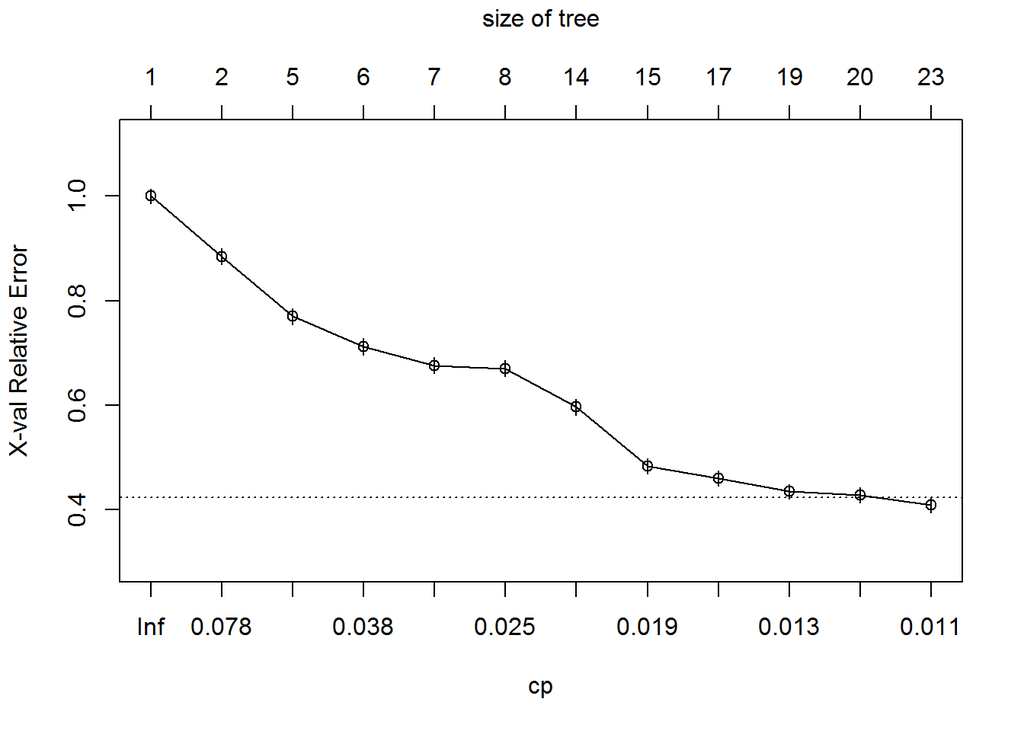

```r
plotcp(rp_trA)
```

```r
loadings(myfact)
```

```
##
## Loadings:
##                   Comp.1 Comp.2 Comp.3 Comp.4 Comp.5 Comp.6 Comp.7 Comp.8
## roll_belt                                                   -0.252
## pitch_belt
## yaw_belt                                                    -0.362
## total_accel_belt
## gyros_belt_x
## gyros_belt_y
## gyros_belt_z
## accel_belt_x
## accel_belt_y
## accel_belt_z                                                 0.401
## magnet_belt_x                                               -0.145
## magnet_belt_y
## magnet_belt_z
## roll_arm                                                     0.133
## pitch_arm
## yaw_arm
## total_accel_arm
## gyros_arm_x
## gyros_arm_y
## gyros_arm_z
## accel_arm_x       -0.194  0.222  0.126
## accel_arm_y                                                  0.416
## accel_arm_z                      0.133         0.128 -0.362
## magnet_arm_x      -0.528  0.497 -0.139               -0.568  0.112
## magnet_arm_y       0.234 -0.194  0.121 -0.105
## magnet_arm_z       0.329 -0.293  0.120 -0.103  0.267 -0.663
## roll_dumbbell                                                       0.150
## pitch_dumbbell                                                      0.117
## yaw_dumbbell                                                        0.127
## gyros_dumbbell_x
## gyros_dumbbell_y
## gyros_dumbbell_z
## accel_dumbbell_x                                                    0.172
## accel_dumbbell_y                                             0.112  0.140
## accel_dumbbell_z                 0.115  0.131                       0.171
## magnet_dumbbell_x         0.137  0.655                              0.609
## magnet_dumbbell_y        -0.117 -0.626         0.114                0.646
```

[output cut: 396 more lines]

```
## SS loadings      1.000   1.000   1.000   1.000   1.000   1.000   1.000
## Proportion Var   0.020   0.020   0.020   0.020   0.020   0.020   0.020
## Cumulative Var   0.588   0.608   0.627   0.647   0.667   0.686   0.706
##                Comp.37 Comp.38 Comp.39 Comp.40 Comp.41 Comp.42 Comp.43
## SS loadings      1.000   1.000   1.000   1.000   1.000   1.000   1.000
## Proportion Var   0.020   0.020   0.020   0.020   0.020   0.020   0.020
## Cumulative Var   0.725   0.745   0.765   0.784   0.804   0.824   0.843
##                Comp.44 Comp.45 Comp.46 Comp.47 Comp.48 Comp.49 Comp.50
## SS loadings      1.000   1.000   1.000   1.000   1.000   1.000    1.00
## Proportion Var   0.020   0.020   0.020   0.020   0.020   0.020    0.02
## Cumulative Var   0.863   0.882   0.902   0.922   0.941   0.961    0.98
##                Comp.51
## SS loadings       1.00
## Proportion Var    0.02
## Cumulative Var    1.00
```

```r
options(max.print = 1000000)
```